# HW 1: Exploración de datos

**Objetivo:** Dar cuenta de las competencias adquiridas en procesos de exploración y análisis preliminar de datos

**Descripción:** Realice los pasos descritos a continuación:

1. Seleccione una base de datos entre las disponibles o incluya una desde su organización. La base de datos debe tener al menos 100 registros y mínimo 7 variables entre numéricas y categóricas. Ofrezca una corta explicación de la base de datos y las variables contenidas con el fin de poner en contexto su procedencia.
2. Realice procesos de carga, selección y descripción de estadísticos descriptivos (función *describe()*). La selección debe ser de mínimo dos variables categóricas y tres variables numéricas. Realice un corto análisis de la descripción.
3. Construya gráficos individuales de cada variable. Realice un corto análisis del comportamiento individual.
4. Construya gráficos de correlación entre variables numéricas y/o categóricas. Realice al menos tres gráficos diferentes. Realice un corto análisis de cada gráfico.
5. Construya gráficos de distribución/densidad individual y conjunta de las variables numéricas y/o categóricas. Realice al menos dos gráficos conjuntos. Realice un corto análisis de cada gráfico.

## Importar librerias

```python
import numpy as np
import pandas as pd
import seaborn as sns
import matplotlib.pyplot as plt
import pandas_profiling
from sklearn.preprocessing import MinMaxScaler
from sklearn.feature_selection import SelectKBest
from sklearn.model_selection import cross_val_score
```

## 1. Recolección de Datos

Incluya en este espacio una descripción de la base de datos que se va explorar, origen de los datos, número de registros, número de variables, tipo de variables, descripción de variables, y otra información que considere valiosa para entender el contexto de los datos.

Descripción:

#### 1. Introducción

Un censo es el procedimiento de adquisición y registro sistemático de información sobre los miembros de una población determinada. El censo es una actividad especial de amplio alcance, que se realiza una vez por década en todo el país. El objetivo es recopilar información sobre la población en general, con el fin de presentar una imagen completa y fiable de la población del país: sus condiciones de vivienda y sus características demográficas, sociales y económicas. La información recogida incluye datos sobre la edad, el sexo, el país de origen, el estado civil, las condiciones de la vivienda, el matrimonio, la educación, el empleo, etc.

#### 1.1 Descripción de los datos

Estos datos fueron extraídos de la base de datos de la Oficina del Censo de 1994 por Ronny Kohavi y Barry Becker (Data Mining and Visualization, Silicon Graphics).

#### Numero de atributos e información

- age: continuous.
- workclass: Private, Self-emp-not-inc, Self-emp-inc, Federal-gov, Local-gov, State-gov, Without-pay, Never-worked. fnlwgt: continuous.
- education: Bachelors, Some-college, 11th, HS-grad, Prof-school, Assoc-acdm, Assoc-voc, 9th, 7th-8th, 12th, Masters, 1st-4th, 10th, Doctorate, 5th-6th, Preschool.
- education-num: continuous.
- marital-status: Married-civ-spouse, Divorced, Never-married, Separated, Widowed, Married-spouse-absent, Married-AF-spouse.
- occupation: Tech-support, Craft-repair, Other-service, Sales, Exec-managerial, Prof-specialty, Handlers-cleaners, Machine-op-inspct, Adm-clerical, Farming-fishing, Transport-moving, Priv-house-serv, Protective-serv, Armed-Forces.
- relationship: Wife, Own-child, Husband, Not-in-family, Other-relative, Unmarried.
- race: White, Asian-Pac-Islander, Amer-Indian-Eskimo, Other, Black.
- sex: Female, Male.
- capital-gain: continuous.
- capital-loss: continuous.
- hours-per-week: continuous.
- native-country: United-States, Cambodia, England, Puerto-Rico, Canada, Germany, Outlying-US(Guam-USVI-etc), India, Japan, Greece, South, China, Cuba, Iran, Honduras, Philippines, Italy, Poland, Jamaica, Vietnam, Mexico, Portugal, Ireland, France, Dominican-Republic, Laos, Ecuador, Taiwan, Haiti, Columbia, Hungary, Guatemala, Nicaragua, Scotland, Thailand, Yugoslavia, El-Salvador, Trinadad&Tobago, Peru, Hong, Holand-Netherlands.
- class: >50K, <=50K

#### Agradecimientos

This dataset named “adult” is found in the UCI machine learning repository http://www.cs.toronto.edu/~delve/data/adult/desc.html The detailed description on the dataset can be found in the original UCI documentation http://www.cs.toronto.edu/~delve/data/adult/adultDetail.html

## 2. Carga, selección y descripción de datos

```python
# incluya aqui código de carga, selección y descripción de datos. Asigne a su base de datos el nombre df

##-----
#INGRESE CÓDIGO AQUI
df = pd.read_csv('adult.csv')
df.head()
###-----
```

|  | age | workclass | fnlwgt | education | educational-num | marital-status | occupation | relationship | race | gender | capital-gain | capital-loss | hours-per-week | native-country | income |
| --- | --- | --- | --- | --- | --- | --- | --- | --- | --- | --- | --- | --- | --- | --- | --- |
| 0 | 25 | Private | 226802 | 11th | 7 | Never-married | Machine-op-inspct | Own-child | Black | Male | 0 | 0 | 40 | United-States | <=50K |
| 1 | 38 | Private | 89814 | HS-grad | 9 | Married-civ-spouse | Farming-fishing | Husband | White | Male | 0 | 0 | 50 | United-States | <=50K |
| 2 | 28 | Local-gov | 336951 | Assoc-acdm | 12 | Married-civ-spouse | Protective-serv | Husband | White | Male | 0 | 0 | 40 | United-States | >50K |
| 3 | 44 | Private | 160323 | Some-college | 10 | Married-civ-spouse | Machine-op-inspct | Husband | Black | Male | 7688 | 0 | 40 | United-States | >50K |
| 4 | 18 | ? | 103497 | Some-college | 10 | Never-married | ? | Own-child | White | Female | 0 | 0 | 30 | United-States | <=50K |

```python
#Reemplazo los nombres de las columnas
df.rename(columns={'relationship': 'relacion','age': 'edad','income': 'ingresos','gender': 'genero','race': 'raza','occupation': 'ocupacion','education': 'educacion','workclass': 'sector laboral','capital-gain': 'capital ganado','educational-num':'años de estudio', 'capital-loss': 'capital perdido', 'native-country': 'pais','hours-per-week': 'horas por semana','marital-status': 'estado marital'}, inplace=True)
df.columns
```

```
Index(['edad', 'sector laboral', 'fnlwgt', 'educacion', 'años de estudio',
       'estado marital', 'ocupacion', 'relacion', 'raza', 'genero',
       'capital ganado', 'capital perdido', 'horas por semana', 'pais',
       'ingresos'],
      dtype='object')
```

```python
#Encunetro caracteres especiales en el data frame
#no conviene tener caracteres especiales para el manejo de los datos
df.isin(['?']).sum(axis=0)
```

```
edad                   0
sector laboral      2799
fnlwgt                 0
educacion              0
años de estudio        0
estado marital         0
ocupacion           2809
relacion               0
raza                   0
genero                 0
capital ganado         0
capital perdido        0
horas por semana       0
pais                 857
ingresos               0
dtype: int64
```

```python
# remplazo los caracteres especiales a nan y luego las elimino de las filas
df['sector laboral'] = df['sector laboral'].replace('?',np.nan)
df['ocupacion'] = df['ocupacion'].replace('?',np.nan)
df['pais'] = df['pais'].replace('?',np.nan)
#eliminando las filas NaN
df.dropna(how='any',inplace=True)
```

```python
df.head()
```

|  | edad | sector laboral | fnlwgt | educacion | años de estudio | estado marital | ocupacion | relacion | raza | genero | capital ganado | capital perdido | horas por semana | pais | ingresos |
| --- | --- | --- | --- | --- | --- | --- | --- | --- | --- | --- | --- | --- | --- | --- | --- |
| 0 | 25 | Private | 226802 | 11th | 7 | Never-married | Machine-op-inspct | Own-child | Black | Male | 0 | 0 | 40 | United-States | <=50K |
| 1 | 38 | Private | 89814 | HS-grad | 9 | Married-civ-spouse | Farming-fishing | Husband | White | Male | 0 | 0 | 50 | United-States | <=50K |
| 2 | 28 | Local-gov | 336951 | Assoc-acdm | 12 | Married-civ-spouse | Protective-serv | Husband | White | Male | 0 | 0 | 40 | United-States | >50K |
| 3 | 44 | Private | 160323 | Some-college | 10 | Married-civ-spouse | Machine-op-inspct | Husband | Black | Male | 7688 | 0 | 40 | United-States | >50K |
| 5 | 34 | Private | 198693 | 10th | 6 | Never-married | Other-service | Not-in-family | White | Male | 0 | 0 | 30 | United-States | <=50K |

### Descripción de datos

```python
df.shape
```

```
(45222, 15)
```

```python
#Utilizo la funcion describe() que por defecto solo lo hara con los campos numericos
df.describe()
```

|  | edad | fnlwgt | años de estudio | capital ganado | capital perdido | horas por semana |
| --- | --- | --- | --- | --- | --- | --- |
| count | 45222.000000 | 4.522200e+04 | 45222.000000 | 45222.000000 | 45222.000000 | 45222.000000 |
| mean | 38.547941 | 1.897347e+05 | 10.118460 | 1101.430344 | 88.595418 | 40.938017 |
| std | 13.217870 | 1.056392e+05 | 2.552881 | 7506.430084 | 404.956092 | 12.007508 |
| min | 17.000000 | 1.349200e+04 | 1.000000 | 0.000000 | 0.000000 | 1.000000 |
| 25% | 28.000000 | 1.173882e+05 | 9.000000 | 0.000000 | 0.000000 | 40.000000 |
| 50% | 37.000000 | 1.783160e+05 | 10.000000 | 0.000000 | 0.000000 | 40.000000 |
| 75% | 47.000000 | 2.379260e+05 | 13.000000 | 0.000000 | 0.000000 | 45.000000 |
| max | 90.000000 | 1.490400e+06 | 16.000000 | 99999.000000 | 4356.000000 | 99.000000 |

De aquí podemos concluir según las variables numéricas

- Edad: La edad promedio de los encuestados es de 38.54 años. La desviación estándar nos indica la dispersión que hay entre los encuestados, aproximadamente unos 13.21 años. El valor mínimo de la edad de los encuestados fue de 17 años y el valor máximo de 90 años. El 25% de los encuestados tiene una edad promedio de 28 años, mientras que el 50% de los encuestados promedia la edad de los 37 años y el 75% de los encuestados promedia los 47 años.
- Años de estudio: Promedio: 10.11 años Estándar: 2.55 años Minimo: 1 año Maximo: 16 años 25% encuestados: 9 años 50% encuestados: 10 años 75% encuestados: 13 años
- Capital ganado: Promedio: 1101.43 usd Estándar: 7506.43 usd Minimo: 0 usd Maximo: 99999 usd 25% encuestados: 0 usd 50% encuestados: 0 usd 75% encuestados: 0 usd
- Capital perdido: Promedio: 88.59 usd Estándar: 404.95 usd Minimo: 0 usd Maximo: 4356.0 usd 25% encuestados: 0 usd 50% encuestados: 0 usd 75% encuestados: 0 usd
- Horas de trabajo x semana Promedio: 40.93 hrs Estándar: 12 hrs Minimo: 1 hr Maximo: 99 hrs 25% encuestados: 40 hrs 50% encuestados: 40 hrs 75% encuestados: 45 hrs

```python
#Utilizo la funcion describe() pero le indico que quiero tomar en cuenta los datos categoricos
df.describe(include='object')
```

|  | sector laboral | educacion | estado marital | ocupacion | relacion | raza | genero | pais | ingresos |
| --- | --- | --- | --- | --- | --- | --- | --- | --- | --- |
| count | 45222 | 45222 | 45222 | 45222 | 45222 | 45222 | 45222 | 45222 | 45222 |
| unique | 7 | 16 | 7 | 14 | 6 | 5 | 2 | 41 | 2 |
| top | Private | HS-grad | Married-civ-spouse | Craft-repair | Husband | White | Male | United-States | <=50K |
| freq | 33307 | 14783 | 21055 | 6020 | 18666 | 38903 | 30527 | 41292 | 34014 |

De aquí podemos rescatar la cantidad de valores unicos que tiene cada columna categórica. Es decir:

- En sector laboral: 7 valores únicos.
- Educación: 16 valores únicos.
- Ocupación: 14 valores únicos.
- Estado marital: 7 valores únicos.
- Relacion: 6 valores únicos.
- Raza: 5 valores únicos.
- Género: 2 valores únicos.
- Pais: 41 valores únicos.
- Ingresos: 2 valores únicos.

De igual manera en la tabla apreciamos según la columna, el valor que más se repite.

## 3. Gráficos individuales

plt.hist(x) permite calcular y dibujar un histograma de la columna x. Es posible establecer el tamaño del gráfico en anteponiendo la función .figure(figsize = (d1,d2)) donde d1 y d2 son las dimensiones en x y y, definir el color de las barras con el parámetro color = 'colorbarra', y nombrar los ejes del diagrama con .xlabel() y .ylabel().

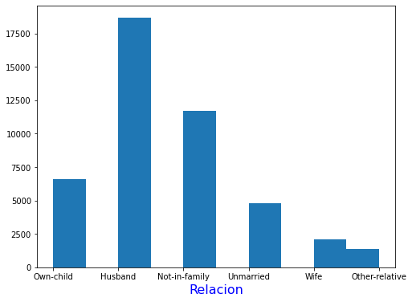

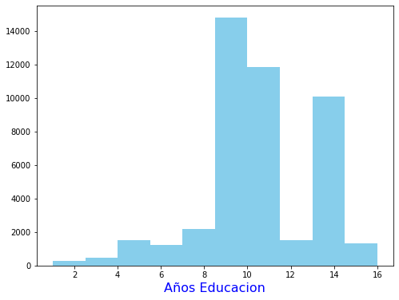

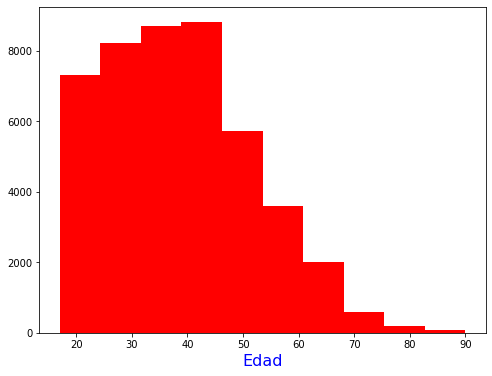

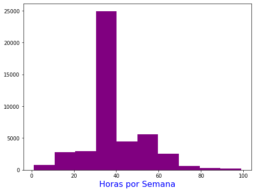

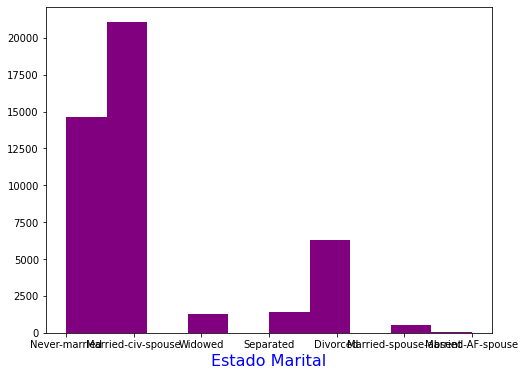

```python
# incluya aqui gráficos individuales de cada variable

##-----
#INGRESE CÓDIGO AQUI
#Creamos el grafico, añadiendo los valores
plt.figure(figsize=(8,6));
plt.hist(df['relacion']);
plt.xlabel('Relacion',fontdict={'size':16,'color':'blue'});

plt.figure(figsize=(8,6));
plt.hist(df['años de estudio'],color='skyblue');
plt.xlabel('Años Educacion',fontdict={'size':16,'color':'blue'});

plt.figure(figsize=(8,6));
plt.hist(df['edad'],color='red');
plt.xlabel('Edad',fontdict={'size':16,'color':'blue'});

plt.figure(figsize=(8,6));
plt.hist(df['horas por semana'],color='purple');
plt.xlabel('Horas por Semana',fontdict={'size':16,'color':'blue'});

plt.figure(figsize=(8,6));
plt.hist(df['estado marital'],color='purple');
plt.xlabel('Estado Marital',fontdict={'size':16,'color':'blue'});
###-----
```

## 4. Gráficos de correlación

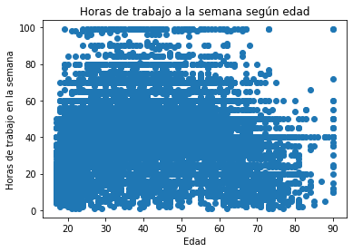

```python
# incluya aqui gráfico de correlación 1

##-----
#INGRESE CÓDIGO AQUI
#Primero convierto la columna categórica ingresos a una numerica
df1 = df[['edad', 'horas por semana']]
#mapeo los datos en datos numerico usando la funcion map
#df1['años de estudio'] = df1['ingresos'].map({'<=50K': 0, '>50K': 1}).astype(int)

plt.scatter(df1['edad'],df1['horas por semana'])
plt.title('Horas de trabajo a la semana según edad')
plt.xlabel("Edad")
plt.ylabel("Horas de trabajo en la semana")
###-----
```

De esta grafica podemos apreciar que la correlación que existe entre estas dos variables (Edad y Horas de trabajo en la semana) es una correlación sin relación, dado que los puntos marcados son muy dispersos, indica que no existe una relación fuerte entre estas dos variables.

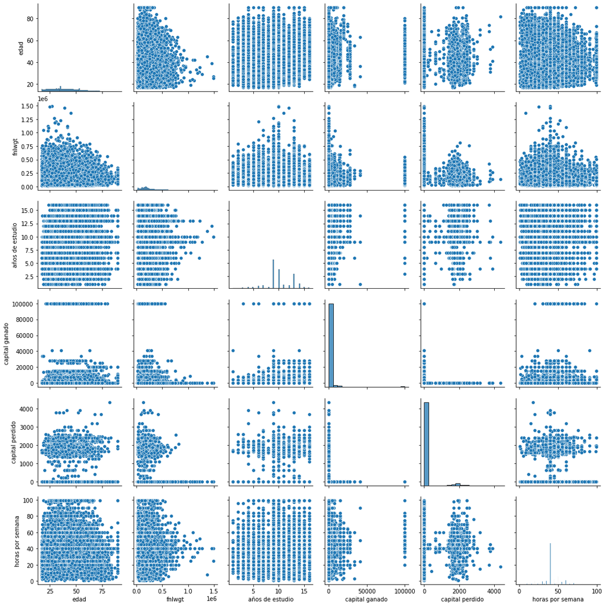

```python
# incluya aqui gráfico de correlación 2

##-----
#INGRESE CÓDIGO AQUI
#sns.jointplot(data=df, x='capital ganado', y='fnlwgt', color='pink', height=10)
sns.pairplot(df)

###-----
```

## > *Con la anterior línea de código, graficamos cada variable para poder ver la correlación entre cada variable de las columnas de nuestro conjunto de datos. Y si bien algo que podemos concluir es que en la mayoría de estos datos numéricos, no podemos ver una correlación entre las variables, dado que los gráficos se ven de manera dispersa, esto indica que no existe relación entre las variables.*

## 5. Gráficos de distribución/densidad individual y conjunta

### 5.1 Analizar los datos y eliminar datos perdidos.

```python
adult_train = df
#Eliminamos la columna fnlwgt porque no es importante para nuestro analisis
adult_train = adult_train.drop('fnlwgt', axis=1)
display(adult_train.head())
display(adult_train.shape)
```

|  | edad | sector laboral | educacion | años de estudio | estado marital | ocupacion | relacion | raza | genero | capital ganado | capital perdido | horas por semana | pais | ingresos |
| --- | --- | --- | --- | --- | --- | --- | --- | --- | --- | --- | --- | --- | --- | --- |
| 0 | 25 | Private | 11th | 7 | Never-married | Machine-op-inspct | Own-child | Black | Male | 0 | 0 | 40 | United-States | <=50K |
| 1 | 38 | Private | HS-grad | 9 | Married-civ-spouse | Farming-fishing | Husband | White | Male | 0 | 0 | 50 | United-States | <=50K |
| 2 | 28 | Local-gov | Assoc-acdm | 12 | Married-civ-spouse | Protective-serv | Husband | White | Male | 0 | 0 | 40 | United-States | >50K |
| 3 | 44 | Private | Some-college | 10 | Married-civ-spouse | Machine-op-inspct | Husband | Black | Male | 7688 | 0 | 40 | United-States | >50K |
| 5 | 34 | Private | 10th | 6 | Never-married | Other-service | Not-in-family | White | Male | 0 | 0 | 30 | United-States | <=50K |

```
(45222, 14)
```

```python
#Examinamos si no hay datos perdidos
adult_train.info()
```

```
<class 'pandas.core.frame.DataFrame'>
Int64Index: 45222 entries, 0 to 48841
Data columns (total 14 columns):
 #   Column            Non-Null Count  Dtype
---  ------            --------------  -----
 0   edad              45222 non-null  int64
 1   sector laboral    45222 non-null  object
 2   educacion         45222 non-null  object
 3   años de estudio   45222 non-null  int64
 4   estado marital    45222 non-null  object
 5   ocupacion         45222 non-null  object
 6   relacion          45222 non-null  object
 7   raza              45222 non-null  object
 8   genero            45222 non-null  object
 9   capital ganado    45222 non-null  int64
 10  capital perdido   45222 non-null  int64
 11  horas por semana  45222 non-null  int64
 12  pais              45222 non-null  object
 13  ingresos          45222 non-null  object
dtypes: int64(5), object(9)
memory usage: 5.2+ MB
```

Lo anterior nos indica que no existen datos perdidos en nuestro DataSet, por lo tanto podemos continuar a graficar

```python
#Primero combinamos los datos
adult_data = pd.concat([adult_train, df])
```

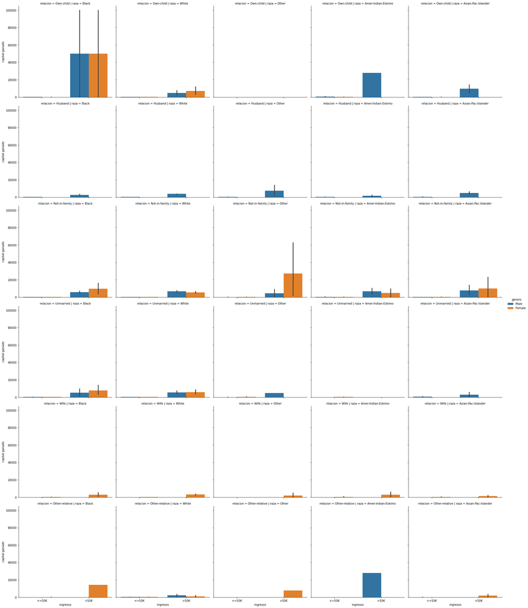

```python
# Resumen de los datos
sns.catplot('ingresos', 'capital ganado', hue='genero', data=adult_data, kind='bar', col='raza', row='relacion')
```

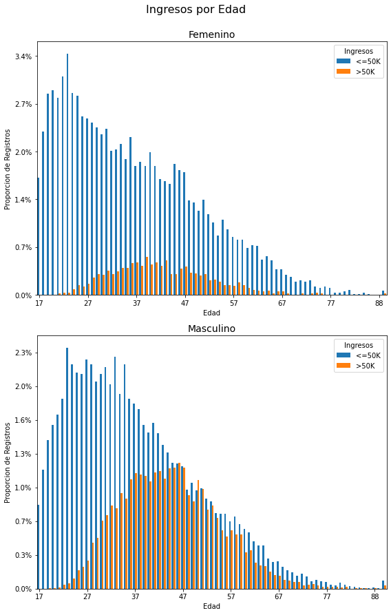

```python
# incluya aqui gráfico de distribución/densidad 1
##-----
#INGRESE CÓDIGO AQUI
fig, ax =plt.subplots(2,1, figsize = (8, 12))
# fig = plt.figure(figsize = (10,13));

# Initiate plot
sns.countplot(x = 'edad', hue = 'ingresos', data = adult_data[adult_data.genero=='Female'], saturation=1, ax=ax[0])
sns.countplot(x = 'edad', hue = 'ingresos', data = adult_data[adult_data.genero=='Male'], saturation=1, ax=ax[1])

# Add titles
ax[0].set_title('Femenino', loc='center', fontsize = 14)
ax[1].set_title('Masculino', loc='center', fontsize = 14)

# Add labels
ax[0].set_xlabel("Edad")
ax[1].set_xlabel("Edad")
ax[0].set_ylabel("Proporcion de Registros")
ax[1].set_ylabel("Proporcion de Registros")

# Add x_axis ticks
new_ticks = [i.get_text() for i in ax[0].get_xticklabels()]
ax[0].set_xticks(range(0, len(new_ticks), 10))
ax[0].set_xticklabels(new_ticks[::10])
ax[1].set_xticks(range(0, len(new_ticks), 10))
ax[1].set_xticklabels(new_ticks[::10])

# Optimize y_axis ticks
total_F = adult_data[adult_data.genero=='Female'].shape[0]*1.
total_M = adult_data[adult_data.genero=='Male'].shape[0]*1.
ax[0].set_yticklabels(map('{:.1f}%'.format, 100*ax[0].yaxis.get_majorticklocs()/total_F))
ax[1].set_yticklabels(map('{:.1f}%'.format, 100*ax[1].yaxis.get_majorticklocs()/total_M))

# Change legend location
ax[0].legend(loc=1, title='Ingresos')
ax[1].legend(loc=1, title='Ingresos')

# Set suptitle
fig.suptitle("Ingresos por Edad", fontsize = 16, y = 1.03)

fig.tight_layout()
fig.show()




###-----
```

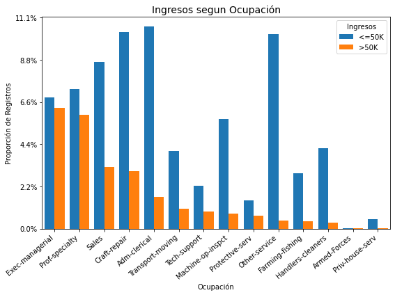

```python
# incluya aqui gráfico de distribución/densidad 2

##-----
#INGRESE CÓDIGO AQUI
order = (adult_data.ocupacion[adult_data.ingresos=='>50K'].value_counts()/adult_data.shape[0]).index

# Plotting the income by age
plt.figure(figsize=(8,6))
ax = sns.countplot(x = 'ocupacion', hue = 'ingresos', order = order, data = adult_data, saturation=1)
ax.set_title('Ingresos segun Ocupación', fontsize = 14)
ax.set_xlabel("Ocupación")
ax.set_ylabel("Proporción de Registros")

ax.set_xticklabels(ax.get_xticklabels(), rotation=40, ha="right")

total = adult_data.shape[0]*1.
ax.set_yticklabels(map('{:.1f}%'.format, 100*ax.yaxis.get_majorticklocs()/total))
ax.legend(loc=1, title='Ingresos')

plt.tight_layout()
plt.show()




###-----
```